# Barking up the wrong tree?

Mon 03/09/2018 11:57

## All models are wrong …

- some are useful
- Categorical And Regression Trees (CART)
- Categorical
  - binomial and multinomial
- Some regression trees

## A "perfect" tree

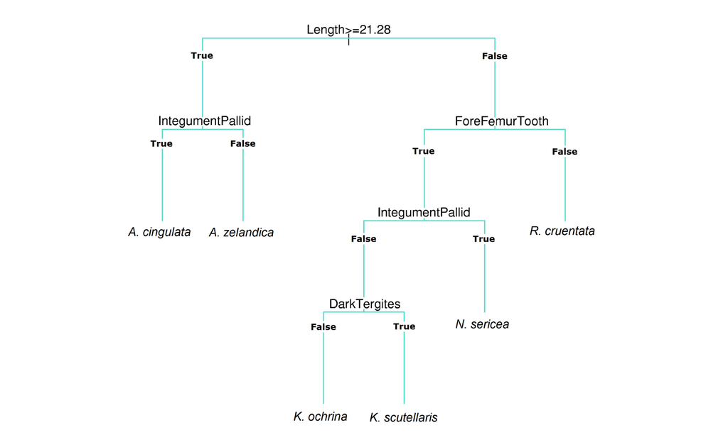

## A "perfect" tree

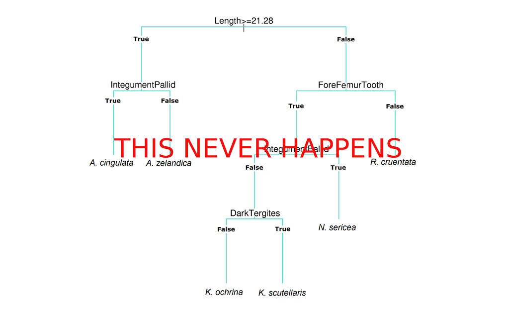

## More likely

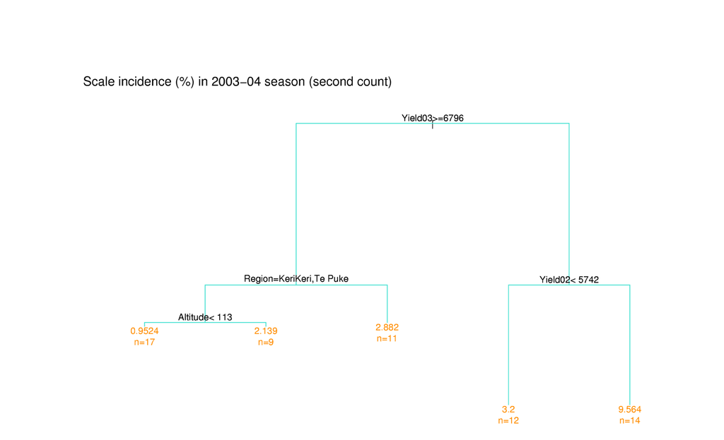

## Single tree

- Looks informative
- very susceptible to small changes in the data
- even to a single data point
- multiple trees from subsets of the data
- look for frequently occurring features

## Example: predicting insect trap catch

- Numerous possible influences
- orchard practices
- landscape parameters
- weather/climate
- Approach is to divide data into training and testing sections
  - build model using large number of samples; observe how often/much parameters influence the dependant variable
  - test the model's ability to predict data held out of model

## Available models, a partial list

- Regression trees
  - rule-based models
  - bagged trees
  - random forests
  - boosted models
  - cubist
- Classification trees
  - logistic regression
  - linear discriminant analysis
  - support vector machines
  - K-nearest neighbours
  - Naive Bayes

## 6 different Regression Tree algorithms

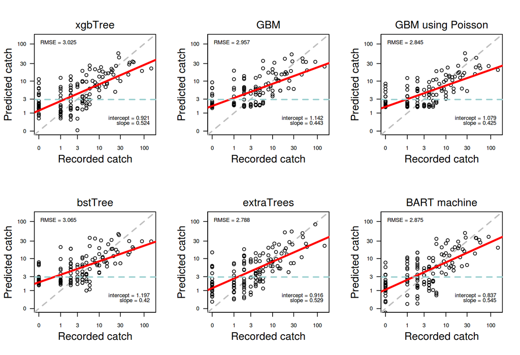

## Accuracy/usefulness indicators

Decide which criterion to use

[output not shown]

## Closer look A

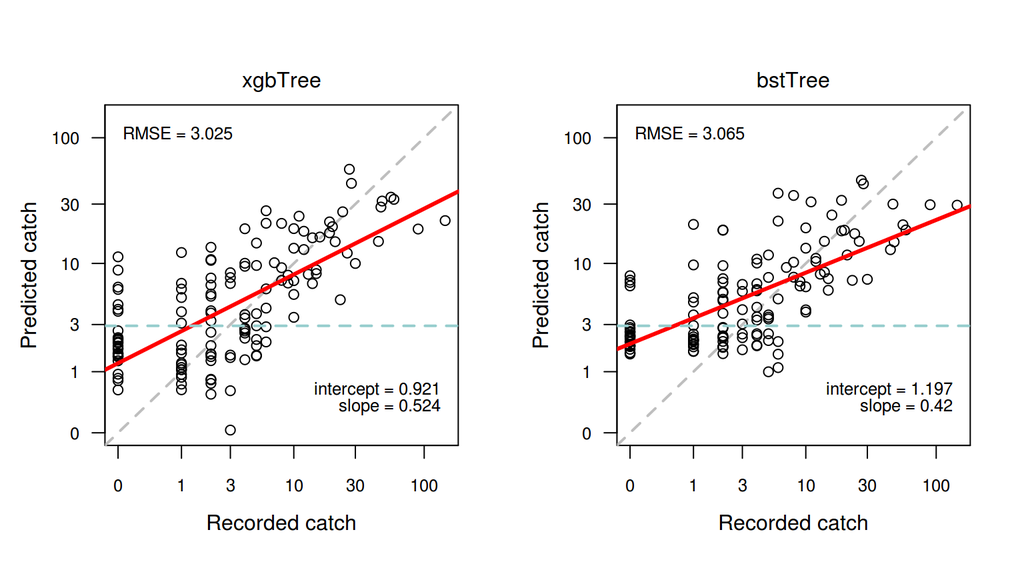

## Closer look B

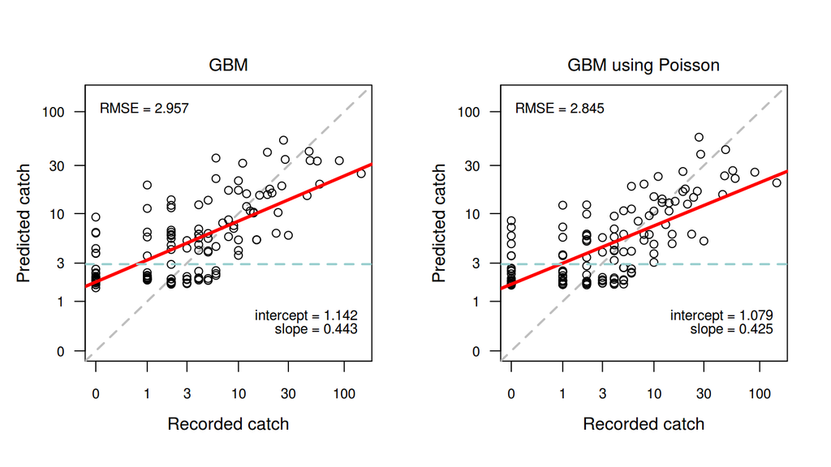

## Closer look: predicting low counts

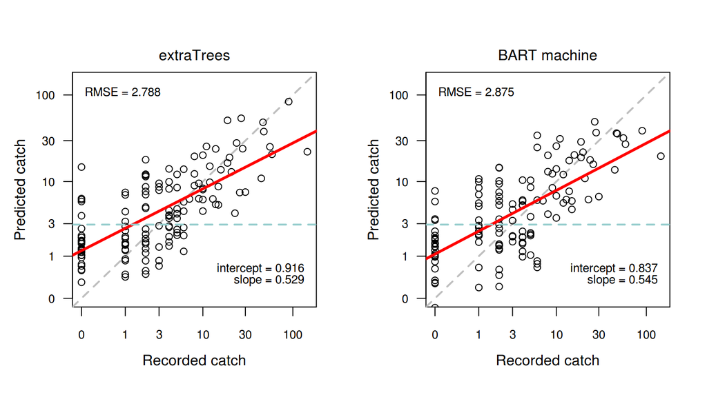

## Conclusion

- little difference which regression tree is used
- if aim is to predict low occurrence, choices are narrower
- use other algorithms such as Support Vector Machines and compare results
- No fixed rule which is the most useful